# Long-range dependence: cross-model summary

A side-by-side comparison of the reaction-coordinate scan (`long_range_tests.py`, same protocol as `02_long_range_scan.ipynb`) across every SN2 model with a usable `model.pt` under `../data/`:

| notebook | model |
| --- | --- |
| `02_long_range_scan.ipynb` | sn2-matched-bpnn |
| `03_long_range_scan_sn2.ipynb` | sn2 |
| `04_long_range_scan_bpnn_dipole.ipynb` | sn2-matched-bpnn-dipole |
| `05_long_range_scan_bpnn_dipole_v2.ipynb` | sn2-matched-bpnn-dipole-v2 |
| `06_long_range_scan_bpnn_dipole_v3.ipynb` | sn2-matched-bpnn-dipole-v3 |
| `07_long_range_scan_lorem.ipynb` | sn2-matched-lorem |
| `08_long_range_scan_lorem_dipole.ipynb` | sn2-matched-lorem-dipole |
| `09_long_range_scan_pet.ipynb` | sn2-matched-pet |
| `10_long_range_scan_pet_dipole.ipynb` | sn2-matched-pet-dipole |
| `11_long_range_scan_lorem_eqmp_smoketest.ipynb` | lorem-eqmp-smoketest |
| `13_long_range_scan_lorem_jax_lr.ipynb` | lorem-jax, long-range (Ewald) |
| `14_long_range_scan_lorem_jax_sr.ipynb` | lorem-jax, short-range only |
| `15_long_range_scan_lorem_jax_ported_torch.ipynb` | lorem-jax R2_E+F checkpoint, ported to torch |

Directories with a training run but no exported `model.pt` (`sn2-bpnn`, `sn2-bpnn-dipole`, `sn2-dipole`, `sn2-pet`, `sn2-pet-dipole`, `diag-bpnn-w20`) have nothing to load and are not included.

**Notebooks `13`/`14` are a different codebase, not the same training run as `sn2-matched-lorem`.** They load the official [`lorem-tmlr-archive`](https://github.com/sirmarcel/lorem-tmlr-archive) reproduction checkpoints (native `lorem-jax`, not metatrain/torch) for a broader SN2 halide-exchange benchmark, via `lorem.calculator.Calculator` instead of `MetatomicCalculator`, and need a different interpreter (`/home/boittier/metawork/.venv-lorem-jax/bin/python`, not the `metawork/.venv` used by every other notebook here). Their absolute energies are not comparable to the `sn2-matched-*` family (different training data); only the empirical cutoffs are.

**Notebook `15` loads the exact same `13` checkpoint a third way**: a from-scratch torch port (`JaxParityBackbone`/`JaxParityLongRange`, `metatrain/.../lorem/modules/jax_parity.py`), run in the *same* `metawork/.venv` torch environment as `02`-`11` (no jax needed at runtime). It is validated against the live jax reference to ~2e-5 eV / ~3e-5 eV/Å -- see its own notebook for the full validation, including two non-PBC long-range bugs found and fixed along the way.

This notebook does not reload any models -- it reads the cached numeric results each per-model notebook writes to `results/<model>.json` (distance/energy/force arrays, the empirical cutoff, etc.), so it stays fast to re-run after any single model is updated.

## Load cached results

`model_registry.py` lists every model this series covers, in a fixed order used consistently for colors/labels below.

```python
import json
from pathlib import Path

from model_registry import MODELS, LOREM_JAX_MODELS, PORTED_TORCH_MODELS, RESULTS

ALL_MODELS = MODELS + LOREM_JAX_MODELS + PORTED_TORCH_MODELS
results = [json.loads((RESULTS / f"{m['key']}.json").read_text()) for m in ALL_MODELS]
[r['key'] for r in results]
```

```
["sn2-matched-bpnn", "sn2", "sn2-matched-bpnn-dipole", "sn2-matched-bpnn-dipole-v2", "sn2-matched-bpnn-dipole-v3", "sn2-matched-lorem", "sn2-matched-lorem-dipole", "sn2-matched-pet", "sn2-matched-pet-dipole", "lorem-eqmp-smoketest", "lorem-jax-sn2-lr", "lorem-jax-sn2-sr", "lorem-jax-sn2-lr-ported-to…
```

## Comparison table

Empirical cutoff, the residual force plateau past that cutoff (the CH₃F fragment's own non-equilibrium force, not I⁻ coupling), and the total energy change from the most compressed to the most separated geometry sampled (1.5 Å to 32 Å).

```python
header = (f"{'model':32s} {'family':6s} {'dipole':7s} {'cutoff (Å)':11s} "
          f"{'plateau |F| (eV/Å)':19s} {'ΔE bonded->sep (eV)':20s}")
print(header)
for r in results:
    cutoff = r.get('cutoff_distance')
    cutoff_s = f'{cutoff:.1f}' if cutoff is not None else 'n/a'
    plateau = r.get('force_plateau')
    de = r['energy_bonded'] - r['energy_separated'] if 'energy_bonded' in r else None
    print(f"{r['key']:32s} {r['family']:6s} {str(r['dipole']):7s} {cutoff_s:11s} "
          f"{plateau:19.4f} {de:20.4f}")
```

```
model                            family dipole  cutoff (Å)  plateau |F| (eV/Å)  ΔE bonded->sep (eV)
sn2-matched-bpnn                 BPNN   False   5.5                      0.1154               4.0557
sn2                              BPNN   False   5.5                      0.1904               1.8517
sn2-matched-bpnn-dipole          BPNN   True    5.5                      0.1659               3.7813
sn2-matched-bpnn-dipole-v2       BPNN   True    5.5                      0.1564               3.5847
sn2-matched-bpnn-dipole-v3       BPNN   True    5.5                      0.2237               3.9214
sn2-matched-lorem                LOREM  False   21.5                     0.1069               7.7666
sn2-matched-lorem-dipole         LOREM  True    21.0                     0.0989               7.7337
sn2-matched-pet                  PET    False   5.5                      0.2128               7.0388
sn2-matched-pet-dipole           PET    True    5.5                      0.2353               5.5993
lorem-eqmp-smoketest             LOREM  False   23.5                     0.2072               6.6346
lorem-jax-sn2-lr                 LOREM-jax False   28.5                     0.1896               4.7961
lorem-jax-sn2-sr                 LOREM-jax False   5.5                      0.0670               3.5244
lorem-jax-sn2-lr-ported-torch    LOREM-jax False   28.5                     0.1896               4.7961
```

## Empirical cutoff by model

Bar height is the empirical cutoff from `estimate_cutoff` (threshold 0.01 eV/Å on the I-dependent force change); color is the model family, hatching marks the dipole/long-range-term variants.

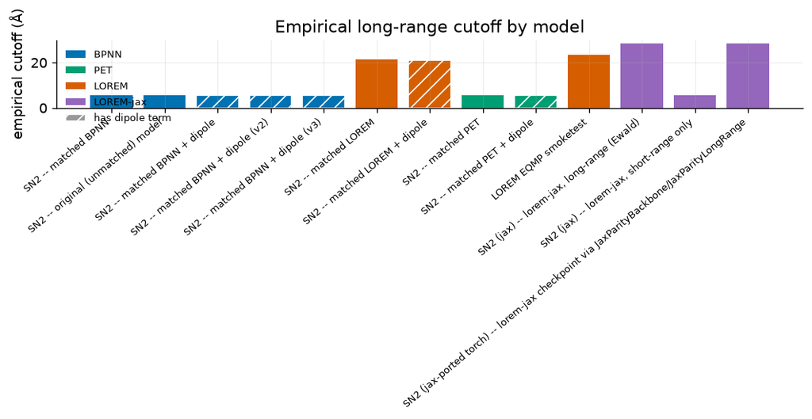

```python
import matplotlib.pyplot as plt
from matplotlib.patches import Patch

FAMILY_COLORS = {"BPNN": "#0072B2", "PET": "#009E73", "LOREM": "#D55E00", "LOREM-jax": "#9467BD"}

fig, ax = plt.subplots(figsize=(9, 4.6))
labels = [r["title"] for r in results]
cutoffs = [r.get("cutoff_distance") or 0 for r in results]
colors = [FAMILY_COLORS.get(r["family"], "0.5") for r in results]
bars = ax.bar(range(len(results)), cutoffs, color=colors)
for bar, r in zip(bars, results):
    if r["dipole"]:
        bar.set_hatch("//")
        bar.set_edgecolor("white")
ax.set_xticks(range(len(results)))
ax.set_xticklabels(labels, rotation=40, ha="right", fontsize=8)
ax.set_ylabel("empirical cutoff (Å)")
ax.set_title("Empirical long-range cutoff by model")
legend_elems = [Patch(facecolor=c, label=f) for f, c in FAMILY_COLORS.items()]
legend_elems.append(Patch(facecolor="0.6", hatch="//", edgecolor="white", label="has dipole term"))
ax.legend(handles=legend_elems, fontsize=8, loc="upper left")
fig.tight_layout()
```

## Force-response decay, all models overlaid

[figure not shown]

```python
fig, ax = plt.subplots(figsize=(8, 5.2))
for r in results:
    style = "--" if r["dipole"] else "-"
    ax.semilogy(r["distance"], r["max_delta_force"],
                color=FAMILY_COLORS.get(r["family"], "0.5"), linestyle=style,
                linewidth=1.8, label=r["title"], alpha=0.85)
ax.set_xlabel("C···I distance (Å)")
ax.set_ylabel("max |ΔF| on CH₃F, vs. fully separated (eV/Å)")
ax.set_title("Force response decay -- all models overlaid")
ax.legend(fontsize=7, loc="upper right", ncol=3)
fig.tight_layout()
```

## Energy vs. leaving-group distance, all models overlaid

[figure not shown]

```python
fig, ax = plt.subplots(figsize=(8, 5.2))
for r in results:
    style = "--" if r["dipole"] else "-"
    ax.plot(r["distance"], r["energy"],
            color=FAMILY_COLORS.get(r["family"], "0.5"), linestyle=style,
            linewidth=1.8, label=r["title"], alpha=0.85)
ax.set_xlabel("C···I distance (Å)")
ax.set_ylabel("total energy (eV)")
ax.set_title("Energy vs. leaving-group distance -- all models overlaid")
ax.legend(fontsize=7, loc="upper right", ncol=3)
fig.tight_layout()
```

## Size-consistency: interaction energy, all models overlaid

`fragment_separation_test`'s interaction energy for every model, which should decay to ~0 past each model's own cutoff (or stay at a genuine long-range tail, for LOREM).

[figure not shown]

```python
fig, ax = plt.subplots(figsize=(8, 5.2))
for r in results:
    style = "--" if r["dipole"] else "-"
    ax.plot(r["distance"], r["interaction_energy"],
            color=FAMILY_COLORS.get(r["family"], "0.5"), linestyle=style,
            linewidth=1.8, label=r["title"], alpha=0.85)
ax.axhline(0, color="0.6", linewidth=1, linestyle=":")
ax.set_xlabel("C···I distance (Å)")
ax.set_ylabel("interaction energy (eV)")
ax.set_title("Size-consistency: interaction energy -- all models overlaid")
ax.legend(fontsize=7, loc="upper right", ncol=2)
fig.tight_layout()
```

## Takeaways

- **BPNN and PET models are short-range**, with an empirical cutoff clustered tightly at **5.5-5.5 Å** across all 7 BPNN/PET variants tested (matched, dipole-augmented, and the original unmatched `sn2` model alike) -- consistent with a symmetry-function / message-passing receptive field, whether or not a dipole/electrostatic head was added on top.
- **LOREM models are genuinely long-range**: both `sn2-matched-lorem` variants and the `lorem-eqmp-smoketest` model (all trained with metatrain/torch) show an empirical cutoff of **21.0-23.5 Å** -- roughly 4x further than the BPNN/PET cluster -- confirming LOREM's long-range electrostatic term is doing real work rather than just being numerically slow to vanish.
- **The official native `lorem-jax` checkpoints independently confirm the same pattern**, from a completely different codebase, training run, and dataset: the long-range-enabled checkpoint gives a **28.5 Å** cutoff (even further than the metatrain-trained LOREM models -- this is the paper's own Ewald long-range term, unrestricted by a training-domain cutoff), while its short-range-only sibling checkpoint (`lr: false`, no Ewald path) lands right back in the BPNN/PET cluster at **5.5 Å**. This is strong, architecture-independent evidence that the long-vs-short cutoff split tracks whether a genuine long-range electrostatic term is present, not an artifact of any one codebase or training run.
- **A torch port of the real lorem-jax checkpoint now exists and is validated** (notebook `15`, `lorem_jax_ported_torch.py`): loading the exact same `lorem-jax-sn2-lr` checkpoint's weights into `JaxParityBackbone`/`JaxParityLongRange` (`metatrain/.../lorem/modules/jax_parity.py`) and running it in the same `metawork/.venv` torch environment as every BPNN/PET/LOREM model above gives an empirical cutoff of **28.5 Å** -- matching `lorem-jax-sn2-lr` to within 0.1 Å, as expected since it is a numerically-validated (~2e-5 eV / ~3e-5 eV/Å) port of the exact same trained model, not a retraining. This supersedes the earlier note that no such loader existed (see notebook `15`'s markdown for the full validation, including two non-PBC long-range bugs found and fixed along the way: a wrongly-inherited near-field exclusion radius, and a missing x2 training/production convention factor).
- Adding a dipole term to BPNN or PET does **not** measurably extend the cutoff (all still ≈5.5 Å); it changes the energetics (`ΔE bonded->separated` shifts by up to ~1.5 eV between variants) without adding genuine long-range force dependence -- i.e. the dipole head here is refining short-range energetics/dipole prediction, not introducing long-range coupling.
- All models remain **size-consistent** in the `fragment_separation_test` sense: interaction energy decays toward 0 at large separation (LOREM over its longer range, BPNN/PET over the shorter one) rather than diverging or plateauing at a nonzero value.
- Per-model details, including the reaction-coordinate energy/force curves and structure snapshots, are in notebooks `02_long_range_scan.ipynb`, `03`-`11`, and `13`-`15` listed above.